# Deutsche Oper Berlin

[figure not shown]

Salome

[figure not shown]

Salome

© 2016 // Monika Rittershaus

[figure not shown]

Salome

© 2016 // Monika Rittershaus

[figure not shown]

Salome

© 2016 // Monika Rittershaus

[figure not shown]

Salome

© 2016 // Monika Rittershaus

[figure not shown]

Salome

© 2016 // Monika Rittershaus

[figure not shown]

Salome

© 2016 // Monika Rittershaus

[figure not shown]

Salome

© 2016 // Monika Rittershaus

[figure not shown]

Salome

© 2016 // Monika Rittershaus

[figure not shown]

Salome

© 2016 // Monika Rittershaus

[figure not shown]

Salome

© 2016 // Monika Rittershaus

[figure not shown]

Salome

© Ruth Tromboukis

[figure not shown]

Salome – The Making-Of

© Ruth Tromboukis

[figure not shown]

Salome

© 2016 // Monika Rittershaus

[figure not shown]

Salome

© 2016 // Monika Rittershaus

[figure not shown]

Salome

© 2016 // Monika Rittershaus

[figure not shown]

Salome

© 2016 // Monika Rittershaus

[figure not shown]

Salome

© 2016 // Monika Rittershaus

[figure not shown]

Salome

© 2016 // Monika Rittershaus

[figure not shown]

Salome

© 2016 // Monika Rittershaus

[figure not shown]

Salome

© 2016 // Monika Rittershaus

[figure not shown]

Salome

© 2016 // Monika Rittershaus

[figure not shown]

Salome

© 2016 // Monika Rittershaus

[figure not shown]

Salome

© 2016 // Monika Rittershaus

[figure not shown]

Salome

© 2016 // Monika Rittershaus

[figure not shown]

Salome

© 2016 // Monika Rittershaus

[figure not shown]

Salome

© 2016 // Monika Rittershaus

[figure not shown]

Salome

© 2016 // Monika Rittershaus

[figure not shown]

Salome

© 2016 // Monika Rittershaus

[figure not shown]

Salome

© 2016 // Monika Rittershaus

[figure not shown]

Salome

© 2016 // Monika Rittershaus

[figure not shown]

Salome

© Ruth Tromboukis

[figure not shown]

Salome – The Making-Of

© Ruth Tromboukis

[figure not shown]

Salome

© 2016 // Monika Rittershaus

[figure not shown]

Salome

© 2016 // Monika Rittershaus

[figure not shown]

Salome

© 2016 // Monika Rittershaus

[figure not shown]

Salome

© 2016 // Monika Rittershaus

[figure not shown]

Salome

© 2016 // Monika Rittershaus

[figure not shown]

Salome

© 2016 // Monika Rittershaus

[figure not shown]

Salome

© 2016 // Monika Rittershaus

# Salome

Richard Strauss (1864 – 1949)

Informationen zum Werk

Musikdrama in einem Aufzug  
Musik und Libretto von Richard Strauss  
nach dem Drama „Salome“ von Oscar Wilde  
in der Übersetzung von Hedwig Lachmann  
Uraufführung am 9. Dezember 1905 in Dresden  
Premiere an der Deutschen Oper Berlin am 24. Januar 2016  
empfohlen ab 16 Jahren

1 Stunde 45 Minuten / Keine Pause

In deutscher Sprache mit deutschen und englischen Übertiteln

Einführung: 45 Minuten vor Vorstellungsbeginn im Rang-Foyer rechts

Termine & Karten

- Repertoire // Wiederaufnahme

  Jan

  So

  B-Preise: € 86,00 / € 66,00 / € 44,00 / € 26,00 / € 20,00
- Repertoire

  27

  20:00

  Jan

  Fr

  B-Preise: € 86,00 / € 66,00 / € 44,00 / € 26,00 / € 20,00
- Repertoire

  17

  20:00

  Mär

  Fr

  B-Preise: € 86,00 / € 66,00 / € 44,00 / € 26,00 / € 20,00
- Zum letzten Mal in dieser Spielzeit // Repertoire

  24

  20:00

  Mär

  Fr

  B-Preise: € 86,00 / € 66,00 / € 44,00 / € 26,00 / € 20,00

Unterstützt von

[figure not shown]

Mit Unterstützung des Förderkreises der Deutschen Oper Berlin e. V.

zum Inhalt

Als „Salomé“ von Oscar Wilde 1896 in Paris zum ersten Mal auf die Bühne kam, verbüßte der Autor in London eine Zuchthausstrafe wegen „grober Unsittlichkeit“. In Großbritannien und auch in den deutschsprachigen Ländern waren nur Privataufführungen des skandalumwitterten Stücks möglich. Eine solche besuchte Richard Strauss 1902 in Max Reinhardts „Kleinem Theater“ in Berlin. Ein Jahr später entschied er sich dazu, Wildes Text zur Grundlage eines Operneinakters zu machen. Die Uraufführung der SALOME 1905 in Dresden war ein durchschlagender Erfolg für den Komponisten. Er fordert darin das Genre heraus: Eine rauschhafte und liebestrunkene Musik kontrastiert das denkbar grässlichste, monströseste Geschehen.  
Die Oper beginnt ohne Vorspiel, und wir werden direkt in Salomes Welt hineinkatapultiert. Salome lebt in einer perfekten bürgerlichen Welt. Sie ist die Tochter der Herodias. Mit ihr lebt sie bei ihrem Stiefvater Herodes – ein mächtiger Mann in einer Männerwelt. Und er hat ein ganz besonderes Verhältnis zu seiner neuen Tochter, der kleinen Prinzessin. Und sie zu ihm. In dieser Familienkonstellation wächst das Kind Salome heran. Und in der Nacht, wenn alle anderen schlafen, imaginiert sie sich ihre eigene Welt. Sie nimmt den Kampf mit ihrem neuen Vater auf, der sie einschüchtert, der sie begehrt, der mit ihr spielt. Diesen Vater, diesen Mann will sie besiegen. Sie erinnert sich an ihre Kindheit, und sie schaut sich selbst zu, wie sie spielt: Vater, Mutter, Kind. Das ist eine hochexplosive Welt, in die sie sich hineinträumt. Aus diesen dunklen Träumen heraus erschafft sich Salome in der Nacht eine Gestalt, einen Gegenentwurf zu der Welt, in der sie sich befindet. Dieses Wesen ist Jochanaan. In dem Familienspiel fungiert er als der Anti-Vater, als die Waffe gegen den Vater, als Erlöser- und Retterfigur. Und wenn der Tag anbricht, sitzt Jochanaan mit Vater, Mutter und dem kriegerischen Kind mit am Tisch. Gemeinsam mit Jochanaan wird Salome diese Ordnung aufsprengen.  
SALOME ist die erste Arbeit von Claus Guth an der Deutschen Oper Berlin. Seit 1999, als er bei den Salzburger Festspielen mit großem Erfolg CRONACA DEL LUOGO von Luciano Berio inszenierte, gehört er zu den gefragtesten Opernregisseuren der Welt. Salzburg, wo er unter anderem die „Da Ponte Trilogie“ [mit Anna Netrebko als Susanna in LE NOZZE DI FIGARO] inszenierte, Bayreuth [DER FLIEGENDE HOLLÄNDER 2003], Zürich, Mailand, München, Hamburg, Frankfurt, Dresden und das Theater an der Wien gehören zu seinen regelmäßigen Stationen wie auch die Staatsoper im Schillertheater.

## Unsere Artikel zum Thema

[figure not shown]

Aufbruch ins Unbewusste

[mehr erfahren](https://deutscheoperberlin.de/de_DE/aufbruch-ins-unbewusste)

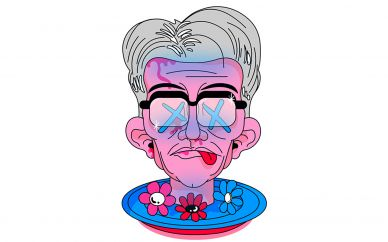

Das Requisit … Jochanaans Kopf

[mehr erfahren](https://deutscheoperberlin.de/de_DE/das-requisit-jochanaans-kopf)

## Unsere Empfehlungen

[figure not shown]

Elektra

[mehr erfahren](https://deutscheoperberlin.de/de_DE/production/elektra.1319711)

[figure not shown]

Arabella

[mehr erfahren](https://deutscheoperberlin.de/de_DE/production/arabella.1319191)

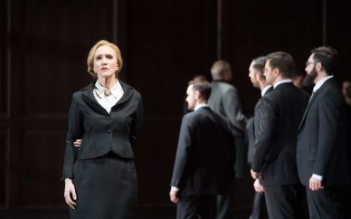

Das Wunder der Heliane

[mehr erfahren](https://deutscheoperberlin.de/de_DE/production/das-wunder-der-heliane.1319677)

[figure not shown]

Verbündete Rivalen – Richard Strauss und Erich Wolfgang Korngold

[mehr erfahren](https://deutscheoperberlin.de/de_DE/production/verbuendete-rivalen-richard-strauss-und-er.1339090)